# Reproducible Research - Peer Assessment: # 1

## Reproducible Research - Peer Assessment: # 1

Assignment work by: csbyjw on: 2014-05-18

## Read in the data (activity.csv)

This code sets the working directory for this assignment repository then attempts to load the file activity.csv from the top level of the directory

```r
library(ggplot2)
setwd("~/Documents/Coursera/Data Science/code")
activity <- read.csv("activity.csv", header = TRUE, stringsAsFactors = FALSE)
```

## Reshaping the data

```r
activity.byday <- aggregate(steps ~ date, data = activity, FUN = sum)
activity.byinterval <- aggregate(steps ~ interval, data = activity, FUN = mean)
str(activity.byday)
```

```
## 'data.frame':    53 obs. of  2 variables:
##  $ date : chr  "2012-10-02" "2012-10-03" "2012-10-04" "2012-10-05" ...
##  $ steps: int  126 11352 12116 13294 15420 11015 12811 9900 10304 17382 ...
```

```r
str(activity.byinterval)
```

```
## 'data.frame':    288 obs. of  2 variables:
##  $ interval: int  0 5 10 15 20 25 30 35 40 45 ...
##  $ steps   : num  1.717 0.3396 0.1321 0.1509 0.0755 ...
```

## What is the mean total number of steps per day?

Histogram of frequency of steps:

```
## stat_bin: binwidth defaulted to range/30. Use 'binwidth = x' to adjust this.
```

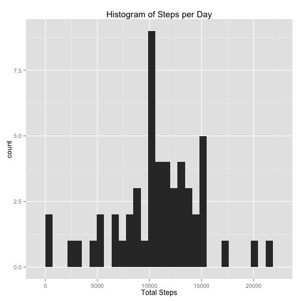

```r
qplot(steps, data = activity.byday, main = "Histogram of Steps per Day", xlab = "Total Steps")
```

Calc the mean and the median:

```r
mean_steps <- mean(activity.byday$steps, na.rm = TRUE)
median_steps <- median(activity.byday$steps, na.rm = TRUE)
```

The mean number of steps per day is 10766 and the median is 10765.

## What is the avg daily activity pattern?

Line plot of avg steps per interval:

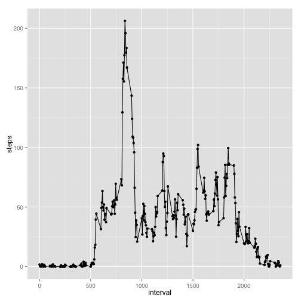

```r
qplot(interval, steps, data = activity.byinterval) + geom_line()
```

Find the interval with the highest avg steps:

```r
max_interval <- activity.byinterval[activity.byinterval$steps == max(activity.byinterval$steps),
    "interval"]
```

The interval with the most steps is 835

## Imputing missing values

```r
missing <- sum(is.na(activity$steps))
```

```r
activity.filled <- activity
for (i in 1:nrow(activity.filled)) {
    r <- activity.filled[i, ]
    if (is.na(r$steps)) {
        activity.filled[i, "steps"] <- activity.byinterval[activity.byinterval$interval ==
            r$interval, "steps"]
    }
}
```

Agg filled data by day and plot the histogram.

```
## stat_bin: binwidth defaulted to range/30. Use 'binwidth = x' to adjust this.
```

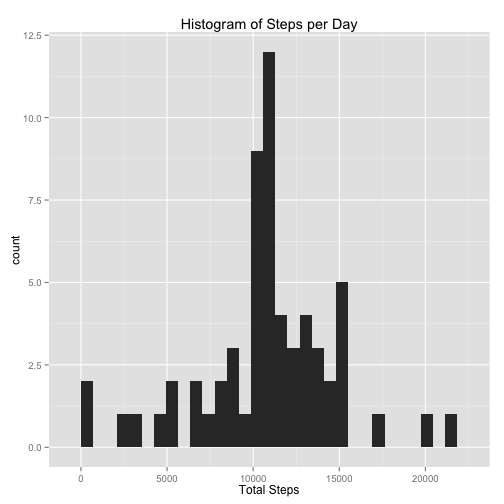

```r
activity.filled.byday <- aggregate(steps ~ date, data = activity.filled, FUN = sum)
qplot(steps, data = activity.filled.byday, main = "Histogram of Steps per Day",
    xlab = "Total Steps")
```

Calc mean and median:

```r
mean_steps_f <- mean(activity.filled.byday$steps, na.rm = TRUE)
median_steps_f <- median(activity.filled.byday$steps, na.rm = TRUE)
```

The mean number of steps per day is 10766 and the median is 10766.

## Are the activity patterns different between weekends and weekdays?

Create a new factor for weekend vs. weekday on activity.filled

```r
activity.filled$weekend <- factor(weekdays(as.Date(activity.filled$date)) %in%
    c("Saturday", "Sunday"), labels = c("Weekday", "Weekend"))
```

Plot the results of mean by interval, faceted by weekend factor.

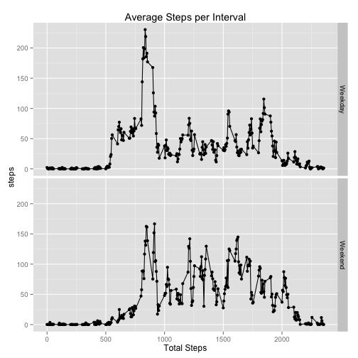

```r
activity.filled.byintv_wday <- aggregate(steps ~ interval + weekend, data = activity.filled,
    FUN = mean)
qplot(interval, steps, data = activity.filled.byintv_wday, facets = weekend ~
    ., main = "Average Steps per Interval", xlab = "Total Steps") + geom_line()
```